# Springboard Capstone Project

Katie Chong

11/24/2018

# Background

This dataset is from Kaggle: “What is cooking?” [link](https://www.kaggle.com/c/whats-cooking-kernels-only)

We only use the training data set in this project, which contains recipes id, type of cuisine, and list of ingredients. We wish to analyze the common ingredients of different cuisines and make predictions based on what patterns we find.

**Importing Data**

**Explore the data**

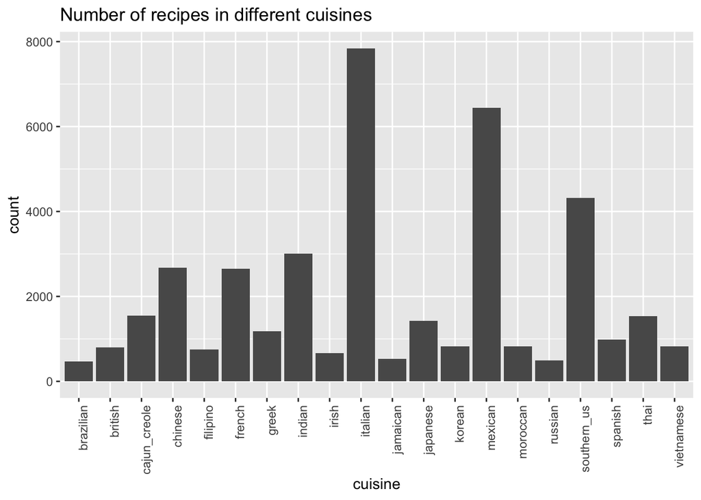

As we can observe from the histogram, Italian has the most recipes in this dataset. Mexican and Southern U.S has a large amount of observations as well.

**Create Corpus**

We use the **tm** package to create a *Corpus* that contains lists of ingredients within the training data. The output shows that there are 39744 “documents”, or in this case recipes, in the corpus.

**Preprocessing**

We want to clean data first, and the common preprocessing procedures in **tm** package include: stemDocument, tolower, removePunctuation, removeWords, stopwords.

For words that are very similar but not identical such as *thigh* and *thighs*, we want to get them into the same “stem” words. For words that have uppercase letters, we want to convert all of them into lowercase.

# Create Document Term Matrix (Bag of Ingredients)

After preprocessing, a *Document Term Matrix* is created. The Term-Document Matrix is a matrix of words (or in this case, ingredients) in all of the recipes, and whether the ingredient appears in each recipe.

```
## <<DocumentTermMatrix (documents: 6, terms: 2992)>>
## Non-/sparse entries: 112/17840
## Sparsity           : 99%
## Maximal term length: 15
## Weighting          : term frequency (tf)
## Sample             :
##       Terms
## Docs   black cheese flour garlic ground oil pepper powder salt water
##   1000     1      0     0      1      1   1      1      0    1     0
##   1001     1      1     0      1      1   0      1      0    1     0
##   1002     0      0     1      0      0   0      0      3    1     3
##   1003     0      1     1      0      0   0      0      0    0     0
##   1004     0      0     1      1      0   1      0      0    1     1
##   1005     0      1     0      0      0   0      0      0    0     1
```

|  | black | cheese | flour | garlic | ground | oil | pepper | powder | salt | water |
| --- | --- | --- | --- | --- | --- | --- | --- | --- | --- | --- |
| 1000 | 1 | 0 | 0 | 1 | 1 | 1 | 1 | 0 | 1 | 0 |
| 1001 | 1 | 1 | 0 | 1 | 1 | 0 | 1 | 0 | 1 | 0 |
| 1002 | 0 | 0 | 1 | 0 | 0 | 0 | 0 | 3 | 1 | 3 |
| 1003 | 0 | 1 | 1 | 0 | 0 | 0 | 0 | 0 | 0 | 0 |
| 1004 | 0 | 0 | 1 | 1 | 0 | 1 | 0 | 0 | 1 | 1 |
| 1005 | 0 | 1 | 0 | 0 | 0 | 0 | 0 | 0 | 0 | 1 |

**Feature selection**

The Term-Document Matrix contains a lot of columns (ingredients). Reducing the number of features, by removing ingredients that don’t occur often, may help with the model (although sometimes unique ingredients may be key to predict certain cuisines).

By selecting only ingredients that appear in at least 1% of the recipes, the number of ingredients in the Document Term Matrix was reduced from 2992 to 270, i.e.: only 9.02% of the full set of ingredients. The DTM is then converted to a data.frame for modelling.

# K-means clustering

Some of the cuisine have a lot of similar ingredients, hence the potential classification errors. We want to explore the similarties bewteen cuisines. Here we use k-means clustering.

**Determined the best number of clusters using elbow method.**

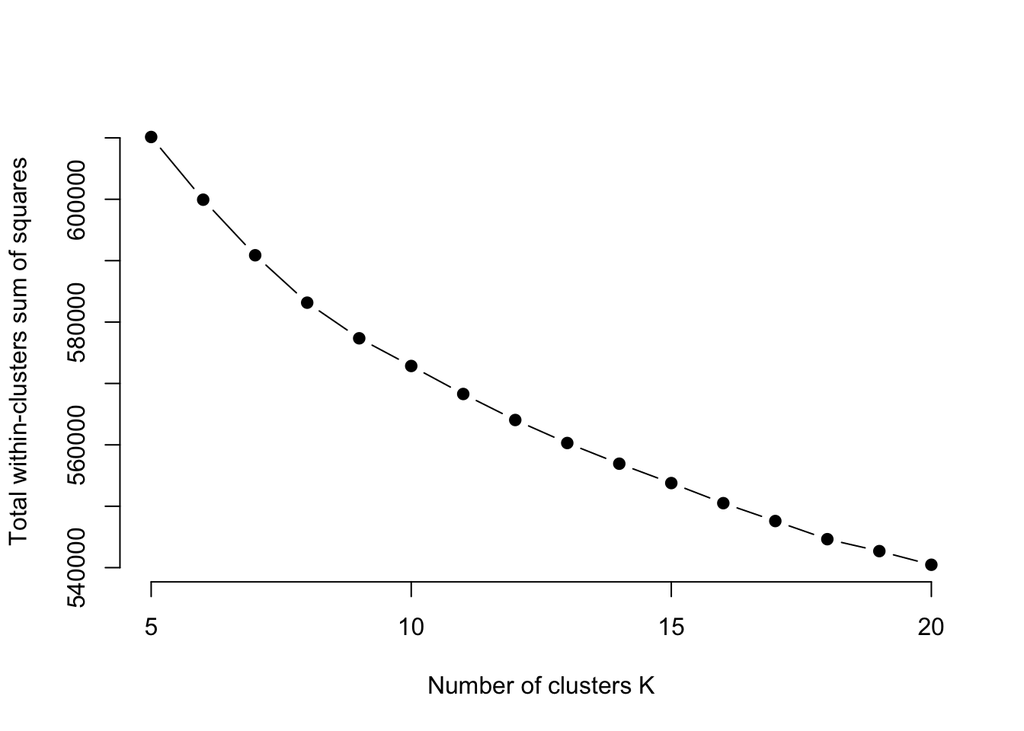

**k-means clustering via `kmeans()`**

# Split training/testing data set

**To estimate the error of the model, the “train” dataset/bag of ingredients is separated into a training and validation set.**

**For later convenience purposes, we create `XTrain`, `YTrain`, `XTest` and `YTest`. `YTrain` and `YTest` are response vectors from the training set and the test set. `XTrain` and `XTest` are design matrices[^2].**

**Error rate function:**

# Classification

**CART model**

A basic model to create from the bag of ingredients is the CART model. This creates a decision tree based on some of the more important ingredients. The tree below shows the decision tree created from the training data.

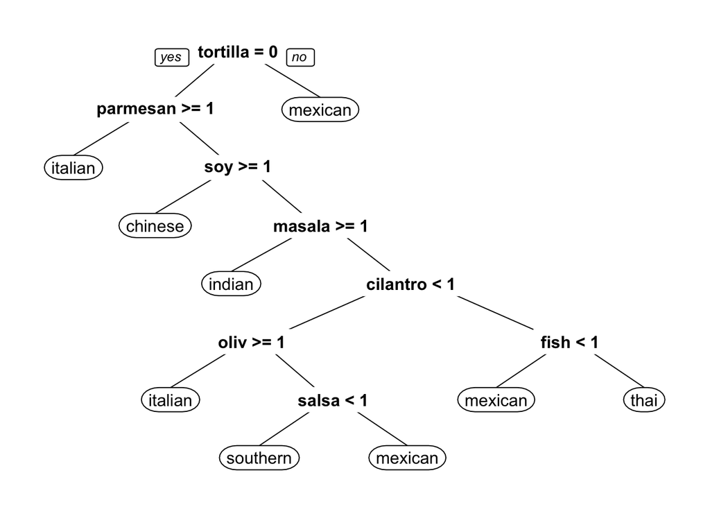

**Evaluating CART model**

We can then evaluate the model’s accuracy and misclassfication rate using a confusion matrix.

```
## [1] 0.417268
```

```
## [1] 0.582732
```

The accuracy of this model is only 41.7% whereas the misclassfication rate is at 58.2%. This prediction is poor and almost exclusively focus on Chinese, Indian, Italian, Mexican, Southern US and Thai.

**We try to improve our CART model by using k-folds cross validation.**

```
## CART
##
## 19811 samples
##   270 predictor
##    20 classes: 'brazilian', 'british', 'cajun_creole', 'chinese', 'filipino', 'french', 'greek', 'indian', 'irish', 'italian', 'jamaican', 'japanese', 'korean', 'mexican', 'moroccan', 'russian', 'southern_us', 'spanish', 'thai', 'vietnamese'
##
## No pre-processing
## Resampling: Cross-Validated (10 fold)
## Summary of sample sizes: 17830, 17831, 17829, 17829, 17828, 17832, ...
## Resampling results across tuning parameters:
##
##   cp          Accuracy   Kappa
##   0.01108522  0.4087122  0.31774753
##   0.03161806  0.3413202  0.21294633
##   0.06405492  0.2271960  0.03716141
##
## Accuracy was used to select the optimal model using the largest value.
## The final value used for the model was cp = 0.01108522.
```

- After determining the best value $cp$ for rpart, we train the `CART` classifier and compute the test error rate.

  |  | train.error | test.error |
  | --- | --- | --- |
  | CART | 0.5982535 | 0.8666683 |
  | knn | NA | NA |
  | random forest | NA | NA |

Obviously, there is no improve on our model. Therefore, we need to furthur analyze the dataset using some other machine learning techniques.

**k-fold Cross-validation (k-fold CV)**

- After determining the best number $k$ for kNN, we train the KNN classifier and compute the test error rate.

```
##               true
## predicted      brazilian british cajun_creole chinese filipino french
##   brazilian          181       6            0       4       15      4
##   british             10     170           11       5       14     48
##   cajun_creole         4       7          692       3        1      9
##   chinese              1       1           10    1777       53      4
##   filipino            23       2           16      58      391     12
##   french              15     116           64      19       11   1119
##   greek                3       0            4       0        0      4
##   indian               7      15            2      23       13      8
##   irish                3      47            4       4        5     34
##   italian             93     143          341     135       54    984
##   jamaican             0       1            3       4        1      0
##   japanese             3      10           20     321       45     18
##   korean               1       0            1     143        7      1
##   mexican             62      21           99      57       25     28
##   moroccan             1       2            1       0        0      4
##   russian              4       7            0       4        2      3
##   southern_us         46     250          262      97      102    355
##   spanish              5       5           16       1        5      9
##   thai                 4       0            0      11        9      1
##   vietnamese           1       1            0       7        2      1
##               true
## predicted      greek indian irish italian jamaican japanese korean mexican
##   brazilian        0     25     1      14       11        7      1      48
##   british          6     11    32      32        9        8      4      25
##   cajun_creole     5      9     0      11       10        0      1      29
##   chinese          1      8     1       2       13      133     73       8
##   filipino         0     23     4      11       39       18     16      35
##   french          58     30    73     313       13       37      6     102
##   greek          355     24     2      26        1        0      0      11
##   indian          21   2129     2      23       20      105      2      48
##   irish            6     14   192      11        4        5      2      17
##   italian        590    238   109    6889       56      113     32     629
##   jamaican         1     12     1       0      178        3      1       4
##   japanese         8     51    10      45       10      802    138      63
##   korean           0      4     0       2        3       58    506       2
##   mexican         20    212    16      99       66       36     18    5050
##   moroccan        15     44     0       4        2        2      0      15
##   russian          0      3     1       4        1        3      1       0
```

[output cut: 11 more lines]

```
##   french             21      87         242      64    6          5
##   greek              16       5           9      15    3          4
##   indian             70       7          14       7   50         15
##   irish               4      21          25       5    2          0
##   italian           262     114         608     508   80         47
##   jamaican            2       0           4       0    1          1
##   japanese            6      15          55      10   88         93
##   korean              1       1           4       1   31         25
##   mexican            47      14         180      92  122         63
##   moroccan          319       0           2       4    2          2
##   russian             2      58           4       2    0          1
##   southern_us        47     108        2926      60   41         48
##   spanish             9       9          10     182    0          0
##   thai                0       0           0       0  755         84
##   vietnamese          0       0           3       1  127        286
```

|  | train.error | test.error |
| --- | --- | --- |
| CART | 0.5982535 | 0.8666683 |
| knn | 0.3462218 | 0.3725140 |
| random forest | NA | NA |

This is a big improvement from the CART model. The misclassfication rate for the test data set this time is at 37.25%.

**Random forest**

```
##
## Call:
##  randomForest(formula = YTrain ~ ., data = ingredients.train,      ntree = 500, importance = TRUE)
##                Type of random forest: classification
##                      Number of trees: 500
## No. of variables tried at each split: 16
##
##         OOB estimate of  error rate: 5.21%
## Confusion matrix:
##              brazilian british cajun_creole chinese filipino french greek
## brazilian          191       0            2       3        0      4     1
## british              0     345            3       3        0     13     4
## cajun_creole         2       3          687       0        0     15     3
## chinese              0       2            2    1290        2     12     0
## filipino             5       2            1      17      310      7     0
## french               0       0            3       3        0   1307     3
## greek                0       2            4       1        1      6   539
## indian               1       0            1       3        0      6     4
## irish                1       4            4       3        1     11     2
## italian              0       0            0       0        0      0     0
## jamaican             4       6            4       1        2      4     0
## japanese             1       1            1      11        2      9     1
## korean               0       0            1       8        0      2     0
## mexican              0       0            1       1        0      5     2
## moroccan             0       0            2       1        0      6     5
## russian              1       4            6       1        0     14     4
## southern_us          0       0            4       3        1      2     0
## spanish              2       3           10       0        1     24     4
## thai                 1       0            0      13        0      0     1
## vietnamese           1       0            0      21        4      2     0
##              indian irish italian jamaican japanese korean mexican
## brazilian         9     0       9        0        0      0      13
## british           9     3      10        0        0      0       3
## cajun_creole      3     0      11        0        3      0      22
## chinese           5     1       6        0        1      0       6
## filipino          4     0       5        0        1      1       8
## french            1     0       2        0        0      0       3
## greek             2     0       8        0        0      0       6
## indian         1484     0       0        0        0      1       4
## irish             9   293      11        0        0      0       8
```

[output cut: 38 more lines]

```
## french       0.0128398792
## greek        0.0738831615
## indian       0.0204620462
## irish        0.1815642458
## italian      0.0007625826
## jamaican     0.1897810219
## japanese     0.1595598349
## korean       0.0668202765
## mexican      0.0066964286
## moroccan     0.1144278607
## russian      0.2071713147
## southern_us  0.0168067227
## spanish      0.2271805274
## thai         0.0662162162
## vietnamese   0.1710526316
```

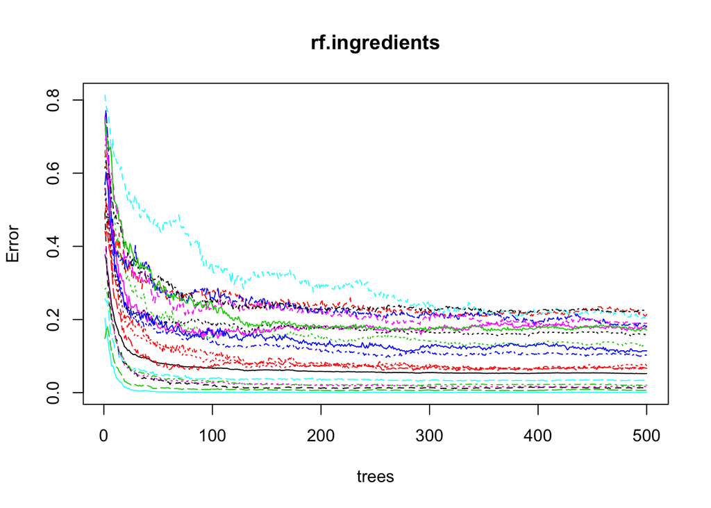

```
##                 brazilian      british cajun_creole     chinese
## beans         13.60102017 10.026918862   6.19754395  6.43981132
## black         14.08600189  5.939356908   3.58464754  6.34301077
## chees          4.84017015  3.925793052   7.56231022  4.57723256
## feta           5.85268150  8.709154912  11.10110333  7.82653605
## garlic        18.45606586 16.978275636  13.88682604  4.06088666
## lettuce        2.80610995  2.545632284   1.55685784  0.71110564
## olives         3.03437652  2.451601492   3.81981013  4.63984065
## onion          6.44049932  6.171588948   2.44824930 11.34356095
## pepper        16.95480505 13.054354353  25.55888335  8.36880866
## purpl          2.27221858  2.207344684   1.14085979  6.21706077
## seasoning     10.92209824  7.057587293  38.83930627  9.89899697
## tomatoes      12.80737981 12.508624742  10.21927964 13.82921944
## corn          11.02077886 12.853945953   5.67471420 15.98483067
## eggs          10.40548368  9.464273069  10.02028843  4.33864094
## flour         11.40502129 15.874514774   7.83326303  8.65111651
## green          7.64727749 13.497076086  17.50377113  2.55120318
## ground        11.21575197  8.118125639   5.28545555  8.54576610
## milk          18.77304172 12.735560168  13.96452620 13.22635115
## oil           17.06875218 14.688176362   6.56258899 17.08463333
## plain          4.42099007  7.861069484   4.54254133  5.38136157
## salt          16.86953436  6.649191924   4.92324334  3.67014075
## thyme          9.27348936  4.904177058  14.92293510 12.53669998
## veget          6.58051831  3.892827309   2.14163494  0.80405899
## yellow         3.19249503  4.046521314  -1.74656405  1.70718988
## breasts        3.70774349  4.508625820   1.31423005  1.42147391
## butter        16.37466748 12.974077560   8.15613571 17.57132423
## chicken       10.70053448  9.400120600   5.39834894  8.76022285
## chilies       11.12747039 13.448459766   9.34683819 10.65611781
## cook           5.35019249  2.139441490   2.33409472 -1.27718627
## mayonaise      1.73659437  4.581264733   3.99565517  6.17571005
## powder         8.05172527  6.919305162   8.32558932  6.11017466
## sauce         20.59641158 14.415919377  12.24045589 20.08419395
## soy           19.43097739 15.294017037  24.08605378 28.66990436
## water          6.06762257  5.170770280   4.77014738  1.64943404
## wheat          1.03697766 -2.318606642   1.85288003  0.53497645
## bay            8.15549110  1.664283506   8.83089470 10.39002777
## boneless       4.13409656  3.988550656   1.57814477  3.07330225
## cayenn         5.13208542  3.296911627  13.59036470  7.80798942
## chili         10.02348846 11.755894456   6.87335857  1.44429743
```

[output cut: 1577 more lines]

```
## celeri               14.146701
## clove                10.217478
## reduc                 7.987672
## parmigiano            7.385915
## reggiano              6.911493
## shoulder              5.940049
## chiles               13.321947
## dill                 29.621354
## meat                 14.808483
## yeast                21.336810
## ketchup              11.949450
## kernels               5.784306
## spring               12.662572
## sprigs               12.468408
## cuisine            5010.351252
```

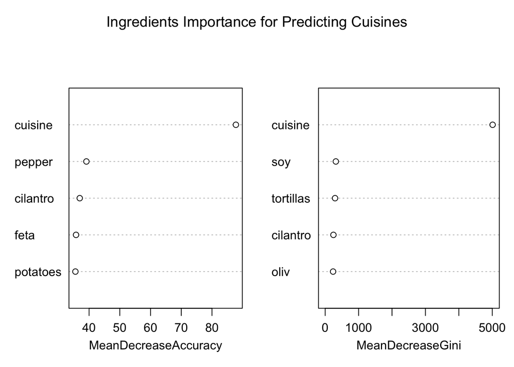

|  | train.error | test.error |
| --- | --- | --- |
| CART | 0.5982535 | 0.8666683 |
| knn | 0.3462218 | 0.3725140 |
| random forest | 0.0001010 | 0.0231816 |